# Menos for, más purrr

Nacho Evangelista

18 de Febrero de 2021

# Listas

## ¿Cómo se definen?

```r
animalitos <- list(
  animales = c("perro", "gato", "elefante", "vaca"),
  acciones = c("ladrar", "maullar", "barritar", "mugir"),
  nombres = list("Dalmata" = "Pongo", "Marley"),
  5)
```

```r
str(animalitos)
```

```
List of 4
 $ animales: chr [1:4] "perro" "gato" "elefante" "vaca"
 $ acciones: chr [1:4] "ladrar" "maullar" "barritar" "mugir"
 $ nombres :List of 2
  ..$ Dalmata: chr "Pongo"
  ..$        : chr "Marley"
 $         : num 5
```

```r
names(animalitos)
```

```
[1] "animales" "acciones" "nombres"  ""
```

## ¿Cómo se accede a sus elementos?

```r
animalitos[["animales"]]
```

```
[1] "perro"    "gato"     "elefante" "vaca"
```

```r
animalitos$acciones
```

```
[1] "ladrar"   "maullar"  "barritar" "mugir"
```

```r
animalitos$"nombres"
```

```
$Dalmata
[1] "Pongo"

[[2]]
[1] "Marley"
```

```r
animalitos[[1]]
```

```
[1] "perro"    "gato"     "elefante" "vaca"
```

```r
animalitos[[4]]
```

```
[1] 5
```

# Purrr

## Operaciones vectorizadas

Muchas operaciones de funcionan en forma vectorizada; aplicadas a vectores, algunas funciones se aplican elemento a elemento (una suerte de iteración)

```r
v <- c(2,5,7)
exp(v)
```

```
[1]    7.389056  148.413159 1096.633158
```

Muchas funciones no tienen esa capacidad

```r
meses <- c("Ene","Feb","Mar","Abr","May","Jun",
           "Jul","Ago","Sep","Oct","Nov","Dic")
which(meses=="Sep")
which(meses==c("Sep","Ene"))
```

```
[1] 9
[1] 9
```

## Función map

Apliquemos algunas funciones a nuestra lista de animalitos

```r
map(animalitos,typeof)
```

```
$animales
[1] "character"

$acciones
[1] "character"

$nombres
[1] "list"

[[4]]
[1] "double"
```

```r
map(animalitos,length)
```

```
$animales
[1] 4

$acciones
[1] 4

$nombres
[1] 2

[[4]]
[1] 1
```

También podemos usar con vectores

```r
v <- c(1,3)
map(v,rnorm)
```

```
[[1]]
[1] -1.624122

[[2]]
[1] -1.1992744  0.2210674  1.5537351
```

```r
# agregamos parámetros adicionales de la función rnorm
v <- c(1,5)
map(v,rnorm,mean=4,sd=2)
```

```
[[1]]
[1] 1.839177

[[2]]
[1] 2.003149 2.340247 6.158427 4.145267 5.428654
```

### Especificando el tipo de salida

Si la función que aplicamos devuelve un único elemento, podemos usar las variantes map_lgl, map_int, map_dbl o map_chr y obtener un vector como resultado

```r
map_chr(animalitos,typeof)
```

```
   animales    acciones     nombres
"character" "character"      "list"    "double"
```

```r
map_int(animalitos,length)
```

```
animales acciones  nombres
       4        4        2        1
```

### Funciones propias

Además de usar funciones predefinidas, podemos definir nuestras propias funciones

```r
sumar_diez <- function(x) return(x+10)
map_dbl(c(-10,4,7),sumar_diez)
```

```
[1]  0 14 17
```

```r
map_dbl(c(-10,4,7),function(x) return(x+10))
```

```
[1]  0 14 17
```

```r
# función anónima (el argumento es siempre .x)
map_dbl(c(-10,4,7), ~.x+10)
```

```
[1]  0 14 17
```

La definición de una función anónima permite ser más explícito en el pasaje de parámetros

```r
v <- c(1,5)
map(v,~rnorm(.x,mean=4,sd=2)) # el argumento es siempre .x!
```

```
[[1]]
[1] 3.643099

[[2]]
[1]  6.5322279 -0.4636375  5.9249820  3.3909356  5.5996509
```

Comparar con

```r
v <- c(1,5)
map(v,rnorm,mean=4,sd=2)
```

También podemos hacer

```r
v <- c(1,8)
map(v,~rnorm(n=2,mean=.x,sd=1)) # el argumento es siempre .x!
```

```
[[1]]
[1] 0.1529277 1.0751253

[[2]]
[1] 10.082434  8.577482
```

## Dos argumentos

Queremos extraer las primeras letras de algunas palabras, donde es una cantidad variable

```r
palabras <- c("recorcholis","nacimiento","rosedal","artista","ion")
cantidad_letras <- c(2,1,3,2,2)
# los argumentos son .x y .y
map2_chr(palabras,cantidad_letras,~substr(.x,1,.y))
```

```
[1] "re"  "n"   "ros" "ar"  "io"
```

Queremos generar dos secuencias de fechas

```r
inicio <- as.Date(c("2018-01-03","2019-03-06"))
fin <- as.Date(c("2018-01-06","2019-03-08"))
map2(inicio,fin,~seq.Date(.x,.y,by="1 day"))
```

```
[[1]]
[1] "2018-01-03" "2018-01-04" "2018-01-05" "2018-01-06"

[[2]]
[1] "2019-03-06" "2019-03-07" "2019-03-08"
```

```r
pelis <- tibble(
cancion = c("Strange Things", "Life is a Highway", "I'm a Believer"),
autor = c("Randy Newman", "Rascal Flatts", "Smash Mouth"),
pelicula = c("Toy Story", "Cars", NA)
)
```

```r
typeof(pelis)
```

```
[1] "list"
```

```r
as.list(pelis)
```

```
$cancion
[1] "Strange Things"    "Life is a Highway" "I'm a Believer"

$autor
[1] "Randy Newman"  "Rascal Flatts" "Smash Mouth"

$pelicula
[1] "Toy Story" "Cars"      NA
```

```r
map_chr(pelis,typeof)
```

```
    cancion       autor    pelicula
"character" "character" "character"
```

```r
map_int(pelis,~sum(is.na(.x)))
```

```
 cancion    autor pelicula
       0        0        1
```

# Dataframes anidados

¿Cómo se construyen las columnas lista y los dataframes anidados?

- En la definición del `tibble`
- Usando `nest` (y `group_by`)
- Como resultado de una operación.

## I. En la definición del tibble

```r
T1 <- tibble(
  v1 = 1:3,
  v2 = c("a","b","c"),
  v3 = list(c("A","B","C")),
  v4 = 10
)
```

```r
# va a dar error
T2 <- tibble(
  v1 = 1:3,
  v2 = c("a","b","c"),
  v3 = list(c("A","B","C"),"B")
)
```

```r
T3 <- tibble(
  v1 = 1:3,
  v2 = c("a","b","c"),
  v3 = list(c("A","B","C"),"perro",5)
)
```

```r
T4 <- tibble(
  v1 = 1:3,
  v2 = c("a","b","c"),
  v3 = list(rnorm(1),rnorm(10),rnorm(100))
)
```

```r
animalitos <- list(animales = c("perro","gato","elefante","vaca"),
               acciones = c("ladrar","maullar","barritar","mugir"),
               nombres = list(c("Pongo","Marley","Golfo"),
                              c("Pelusa","Tom"),
                              c("Tantor","Dumbo"),
                              c("Oscar")))

as_tibble(animalitos)
```

```
# A tibble: 4 x 3
  animales acciones nombres
  <chr>    <chr>    <list>
1 perro    ladrar   <chr [3]>
2 gato     maullar  <chr [2]>
3 elefante barritar <chr [2]>
4 vaca     mugir    <chr [1]>
```

## II. Usando nest

```
                   mpg cyl disp  hp drat    wt  qsec vs am
Mazda RX4         21.0   6  160 110 3.90 2.620 16.46  0  1
Mazda RX4 Wag     21.0   6  160 110 3.90 2.875 17.02  0  1
Datsun 710        22.8   4  108  93 3.85 2.320 18.61  1  1
Hornet 4 Drive    21.4   6  258 110 3.08 3.215 19.44  1  0
Hornet Sportabout 18.7   8  360 175 3.15 3.440 17.02  0  0
Valiant           18.1   6  225 105 2.76 3.460 20.22  1  0
                  gear carb
Mazda RX4            4    4
Mazda RX4 Wag        4    4
Datsun 710           4    1
Hornet 4 Drive       3    1
Hornet Sportabout    3    2
Valiant              3    1
```

```r
mtcars %>%
  group_by(gear,carb) %>%
  nest()
```

```
# A tibble: 11 x 3
# Groups:   gear, carb [11]
    gear  carb data
   <dbl> <dbl> <list>
 1     4     4 <tibble [4 x 9]>
 2     4     1 <tibble [4 x 9]>
 3     3     1 <tibble [3 x 9]>
 4     3     2 <tibble [4 x 9]>
 5     3     4 <tibble [5 x 9]>
 6     4     2 <tibble [4 x 9]>
 7     3     3 <tibble [3 x 9]>
 8     5     2 <tibble [2 x 9]>
 9     5     4 <tibble [1 x 9]>
10     5     6 <tibble [1 x 9]>
# ... with 1 more row
```

```r
mtcars %>%
  nest(datos = !c(gear,carb))
```

```
# A tibble: 11 x 3
    gear  carb datos
   <dbl> <dbl> <list>
 1     4     4 <tibble [4 x 9]>
 2     4     1 <tibble [4 x 9]>
 3     3     1 <tibble [3 x 9]>
 4     3     2 <tibble [4 x 9]>
 5     3     4 <tibble [5 x 9]>
 6     4     2 <tibble [4 x 9]>
 7     3     3 <tibble [3 x 9]>
 8     5     2 <tibble [2 x 9]>
 9     5     4 <tibble [1 x 9]>
10     5     6 <tibble [1 x 9]>
# ... with 1 more row
```

## III. Como resultado de una operación

Queremos unir estas dos tablas reemplazando los códigos del casting por los personajes.

```r
peleas <- tibble::tribble(
 ~pelea, ~horario,                      ~casting,
      1,  "20:30",        "gsf901,fez195,yfm179",
      2,  "20:50",               "thf028,yfm179",
      3,  "19:40", "jfa348,fez195,gky651,wpx281",
      4,  "21:00",               "thf028,fez195")
```

```r
luchadores <- tibble::tribble(
   ~codigo,           ~nombre,
  "gsf901",  "Vicente Viloni",
  "thf028",     "Hip Hop Man",
  "wpx281",         "La Masa",
  "fez195", "Fulgencio Mejía",
  "jfa348",        "Mc Floyd",
  "phb625",     "Mario Morán",
  "gky651",      "Rulo Verde",
  "yfm179",    "Steve Murphy")
```

```r
peleas %>%
  mutate(casting_split = strsplit(casting, split = ",")) %>%
  select(-horario,-casting) %>%
  unnest(casting_split) %>%
  left_join(luchadores, by = c("casting_split" = "codigo"))
```

```
# A tibble: 11 x 3
   pelea casting_split nombre
   <dbl> <chr>         <chr>
 1     1 gsf901        Vicente Viloni
 2     1 fez195        Fulgencio Mejía
 3     1 yfm179        Steve Murphy
 4     2 thf028        Hip Hop Man
 5     2 yfm179        Steve Murphy
 6     3 jfa348        Mc Floyd
 7     3 fez195        Fulgencio Mejía
 8     3 gky651        Rulo Verde
 9     3 wpx281        La Masa
10     4 thf028        Hip Hop Man
# ... with 1 more row
```

# Ejemplos

## 1. Identificar el mes

Queremos obtener el número de mes a partir de la abreviatura

```r
datos <- tibble::tribble(
 ~id,~dia,  ~mes, ~año,
   1,  15, "Sep", 2019,
   2,   6, "oct", 2021,
   3,   3, "Ene", 2020,
   4,  31, "dic", 2019)
```

Idea

1. Armar un vector con las abreviaturas de los meses
2. Usar la función junto con

```r
meses <- c("Ene","Feb","Mar","Abr","May","Jun",
           "Jul","Ago","Sep","Oct","Nov","Dic")
```

```r
which(meses=="Sep")
```

```
[1] 9
```

```r
which(meses==c("Sep","Ene"))
```

```
[1] 9
```

```r
datos %>%
  mutate(mes_n = map(mes,~which(meses==.x)))
```

```
# A tibble: 4 x 5
     id   dia mes     año mes_n
  <dbl> <dbl> <chr> <dbl> <list>
1     1    15 Sep    2019 <int [1]>
2     2     6 oct    2021 <int [0]>
3     3     3 Ene    2020 <int [1]>
4     4    31 dic    2019 <int [0]>
```

```r
datos %>%
  mutate(mes_n = map(mes,~which(toupper(meses)==toupper(.x))))
```

```
# A tibble: 4 x 5
     id   dia mes     año mes_n
  <dbl> <dbl> <chr> <dbl> <list>
1     1    15 Sep    2019 <int [1]>
2     2     6 oct    2021 <int [1]>
3     3     3 Ene    2020 <int [1]>
4     4    31 dic    2019 <int [1]>
```

```r
datos %>%
  mutate(mes_n = map_int(mes,~which(toupper(meses)==toupper(.x))))
```

```
# A tibble: 4 x 5
     id   dia mes     año mes_n
  <dbl> <dbl> <chr> <dbl> <int>
1     1    15 Sep    2019     9
2     2     6 oct    2021    10
3     3     3 Ene    2020     1
4     4    31 dic    2019    12
```

## 2. Secuencia de fechas

Contamos con los movimientos de dos empresas. Interesa tener la serie temporal de eventos para cada empresa y producto.

```r
datos <- tibble::tribble(
  ~empresa, ~producto,       ~fecha, ~evento,
       "A",      "A1", "02/06/2018",     112,
       "A",      "A1", "06/06/2018",     141,
       "A",      "A1", "13/07/2018",     119,
       "A",      "A2", "01/05/2018",      53,
       "A",      "A2", "04/05/2018",      67,
       "B",      "B1", "01/07/2018",     127,
       "B",      "B1", "05/07/2018",     301,
       "B",      "B1", "10/07/2018",      98,
       "B",      "B1", "11/07/2018",     167)
datos$fecha <- as.Date(datos$fecha,format = "%d/%m/%Y")
```

Idea:

1. Determinar la primera y última fecha de cada grupo
2. Generar una secuencia de fechas (`seq.Date`) para cada grupo y construir una tabla con todas las fechas
3. Unir esta tabla con la original

```r
fechas_todas <-
  datos %>%
  group_by(empresa, producto) %>%
  summarise(fecha_inicial = min(fecha),
            fecha_final = max(fecha)) %>%
  mutate(fechas = map2(fecha_inicial,
                       fecha_final,
                       ~seq.Date(.x,.y,by="1 day"))) %>%
  select(-fecha_inicial,-fecha_final)
fechas_todas %>%
  unnest(fechas) %>%
  left_join(datos, by = c("empresa","producto","fechas" = "fecha"))
```

```
# A tibble: 57 x 4
# Groups:   empresa [2]
   empresa producto fechas     evento
   <chr>   <chr>    <date>      <dbl>
 1 A       A1       2018-06-02    112
 2 A       A1       2018-06-03     NA
 3 A       A1       2018-06-04     NA
 4 A       A1       2018-06-05     NA
 5 A       A1       2018-06-06    141
 6 A       A1       2018-06-07     NA
 7 A       A1       2018-06-08     NA
 8 A       A1       2018-06-09     NA
 9 A       A1       2018-06-10     NA
10 A       A1       2018-06-11     NA
# ... with 47 more rows
```

## 3. Abrir varios archivos a la vez

En el directorio de trabajo hay varios archivos que debemos abrir y leer.

```r
# hay que tener algun archivo csv en el directorio de trabajo
list.files(pattern="archivo")
```

Idea:

1. Listar los archivos y construir un `tibble`
2. Leer cada archivo con `read.csv`
3. *Desanidar*

```r
# hay que tener algun archivo csv en el directorio de trabajo
list.files(pattern="archivo") %>%
  tibble(archivos = .) %>%
  mutate(contenido = map(archivos,read.csv)) %>%
  unnest(contenido)
```

## 4. Múltiples salidas

Queremos analizar frases de canciones y determinar: a) cantidad de palabras, b) cantidad de preposiciones

```
# A tibble: 7 x 3
  banda       cancion          frase
  <chr>       <chr>            <chr>
1 Los Wachit~ Este es el pasi~ El que no hace palmas es un ~
2 La Base     Sabor sabrosón   Según la moraleja, el que no~
3 Damas Grat~ Me va a extrañar ATR perro cumbia cajeteala p~
4 Altos Cumb~ No voy a llorar  Andy, fijate que volvieron, ~
5 Los Pibes ~ Llegamos los Pi~ Llegamos los pibes chorros q~
6 La Liga     Se re pudrió     El que no hace palmas tiene ~
7 Los Palmer~ La cola          A la una, a la dos, a la one~
```

Idea:

1. Definir una función que devuelva ambas cantidades
2. Aplicarla a cada frase

```r
analizar_frase <- function(cancion){
  preposiciones <- c("a", "ante", "bajo", "cabe", "con",
                     "contra", "de", "desde", "durante",
                     "en", "entre", "hacia", "hasta", "mediante",
                     "para", "por", "según", "sin", "so", "sobre",
                     "tras", "versus", "vía")

  palabras <- strsplit(cancion," ") %>% unlist

  cant_palabras <- length(palabras)

  cant_preposiciones <- sum(palabras %in% preposiciones)

  return(list(cant_palabras = cant_palabras,
              cant_preposiciones = cant_preposiciones))
  }
```

```r
datos %>%
  mutate(resultado = map(frase,analizar_frase)) %>%
  unnest_wider(resultado)
```

```
# A tibble: 7 x 5
  banda   cancion   frase     cant_palabras cant_preposicio~
  <chr>   <chr>     <chr>             <int>            <int>
1 Los Wa~ Este es ~ El que n~             8                0
2 La Base Sabor sa~ Según la~            12                0
3 Damas ~ Me va a ~ ATR perr~             6                0
4 Altos ~ No voy a~ Andy, fi~             8                0
5 Los Pi~ Llegamos~ Llegamos~            10                1
6 La Liga Se re pu~ El que n~             9                1
7 Los Pa~ La cola   A la una~            15                2
```

## 5. Múltiples plots

Queremos construir un conjunto de plots mostrando los ajustes de polinomios de distinto orden a los puntos del dataset.

```r
datos <- tibble::tribble(
 ~`x`,  ~`y`,
  211,   184,
  230,   147,
  587,   413,
  414,   252,
  419,   252,
  157,   272,
  327,   158,
  222,   158,
  451,   249,
  296,   127)
```

Idea:

1. Combinamos los datos con cada uno de los posibles órdenes del polinomio
2. `group by` + `nest`
3. Aplicar una función que cree el gráfico utilizando `map`

```r
plots <- crossing(orden = 1:6, datos) %>%
  nest(datos = !orden) %>%
  ungroup() %>%
  mutate(plot = map2(datos, orden,
                     function(.x, .y) {
                       p<-ggplot(.x, aes(x = x, y = y)) +
                         geom_point() +
                         stat_smooth(
                           method = "lm", se = FALSE,
                           formula = y ~ poly(x, degree = .y),
                           colour = "maroon1") +
                         theme_minimal()
                       return(p)
                     }))
```

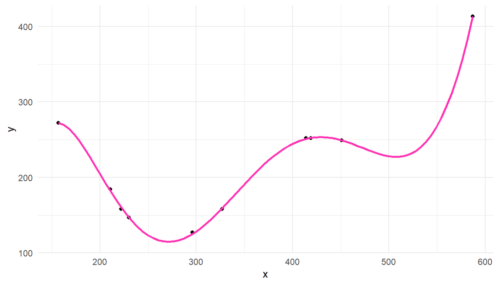

```r
plots$plot[[6]]
```

## 6. K-fold cross validation

```r
K <- 3
data <- mtcars %>%
  mutate(fold = rep(1:K,length.out=nrow(.))) %>%
  arrange(fold) %>%
  group_by(fold) %>%
  nest() %>%
  mutate(dummy = 1)
```

```r
train_test <- data %>%
  inner_join(data, by="dummy") %>%
  select(-dummy) %>%
  filter(fold.y != fold.x) %>%
  group_by(fold.x) %>%
  summarise(test = list(first(data.x)),
            train = list(bind_rows(data.y)))
```

```r
train_test %>%
  mutate(modelo = map(train,~lm(mpg ~ wt,data=.x)),
         pred = map2(modelo,test,~predict(.x,.y)),
         real = map(test,"mpg"))
```

```
# A tibble: 3 x 6
  fold.x test          train         modelo pred     real
   <int> <list>        <list>        <list> <list>   <list>
1      1 <tibble [11 ~ <tibble [21 ~ <lm>   <dbl [1~ <dbl [~
2      2 <tibble [11 ~ <tibble [21 ~ <lm>   <dbl [1~ <dbl [~
3      3 <tibble [10 ~ <tibble [22 ~ <lm>   <dbl [1~ <dbl [~
```

# Extra

## Más de dos argumentos: pmap

```r
bolilleros <- list(1:6,1:50,1:100)
cant <- list(6,5,4)
con_reemplazo <- list(TRUE,FALSE,FALSE)

pmap(list(bolilleros,cant,con_reemplazo),
     ~sample(x = ..1, size = ..2, replace = ..3))
```

```
[[1]]
[1] 1 4 6 4 2 2

[[2]]
[1] 12 50 14 19 25

[[3]]
[1] 10 23 69 11
```

## Manejo de errores

```r
c(list.files(pattern="archivo"),"archivo_4.csv") %>%
  tibble(archivos = .) %>%
  mutate(contenido = map(archivos,read.csv)) %>%
  unnest(contenido)
```

```r
possibly_read.csv <- possibly(read.csv,otherwise = data.frame())

c(list.files(pattern="archivo"),"archivo_4.csv") %>%
  tibble(archivos = .) %>%
  mutate(contenido = map(archivos,possibly_read.csv))
```

```
# A tibble: 4 x 2
  archivos      contenido
  <chr>         <list>
1 archivo_1.csv <df[,5] [6 x 5]>
2 archivo_2.csv <df[,5] [6 x 5]>
3 archivo_3.csv <df[,5] [6 x 5]>
4 archivo_4.csv <df[,0] [0 x 0]>
```